# Risk Factor Analysis

## Outcome Variable

**Outcome Variable:** ever_stunted

## Predictor Variables

**Intervention Variable:** mhtcm

**Adjustment Set:**

unadjusted

## Stratifying Variables

The analysis was stratified on these variable(s):

- agecat
- studyid

The following strata were considered:

- agecat: 12 months, studyid: ki0047075b-MAL-ED
- agecat: 12 months, studyid: ki1000304b-SAS-FoodSuppl
- agecat: 12 months, studyid: ki1017093-NIH-Birth
- agecat: 12 months, studyid: ki1017093b-PROVIDE
- agecat: 12 months, studyid: ki1017093c-NIH-Crypto
- agecat: 12 months, studyid: ki1066203-TanzaniaChild2
- agecat: 12 months, studyid: ki1101329-Keneba
- agecat: 12 months, studyid: ki1112895-Guatemala BSC
- agecat: 12 months, studyid: ki1126311-ZVITAMBO
- agecat: 12 months, studyid: ki1135781-COHORTS
- agecat: 12 months, studyid: ki1148112-LCNI-5
- agecat: 18 months, studyid: ki0047075b-MAL-ED
- agecat: 18 months, studyid: ki1000304b-SAS-FoodSuppl
- agecat: 18 months, studyid: ki1017093-NIH-Birth
- agecat: 18 months, studyid: ki1017093b-PROVIDE
- agecat: 18 months, studyid: ki1017093c-NIH-Crypto
- agecat: 18 months, studyid: ki1066203-TanzaniaChild2
- agecat: 18 months, studyid: ki1101329-Keneba
- agecat: 18 months, studyid: ki1112895-Guatemala BSC
- agecat: 18 months, studyid: ki1126311-ZVITAMBO
- agecat: 18 months, studyid: ki1135781-COHORTS
- agecat: 18 months, studyid: ki1148112-LCNI-5
- agecat: 24 months, studyid: ki0047075b-MAL-ED
- agecat: 24 months, studyid: ki1000304b-SAS-FoodSuppl
- agecat: 24 months, studyid: ki1017093-NIH-Birth
- agecat: 24 months, studyid: ki1017093b-PROVIDE
- agecat: 24 months, studyid: ki1017093c-NIH-Crypto
- agecat: 24 months, studyid: ki1066203-TanzaniaChild2
- agecat: 24 months, studyid: ki1101329-Keneba
- agecat: 24 months, studyid: ki1126311-ZVITAMBO
- agecat: 24 months, studyid: ki1135781-COHORTS
- agecat: 24 months, studyid: ki1148112-LCNI-5
- agecat: 3 months, studyid: ki0047075b-MAL-ED
- agecat: 3 months, studyid: ki1017093-NIH-Birth
- agecat: 3 months, studyid: ki1017093b-PROVIDE
- agecat: 3 months, studyid: ki1017093c-NIH-Crypto
- agecat: 3 months, studyid: ki1066203-TanzaniaChild2
- agecat: 3 months, studyid: ki1101329-Keneba
- agecat: 3 months, studyid: ki1126311-ZVITAMBO
- agecat: 3 months, studyid: ki1135781-COHORTS
- agecat: 6 months, studyid: ki0047075b-MAL-ED
- agecat: 6 months, studyid: ki1000304b-SAS-FoodSuppl
- agecat: 6 months, studyid: ki1017093-NIH-Birth
- agecat: 6 months, studyid: ki1017093b-PROVIDE
- agecat: 6 months, studyid: ki1017093c-NIH-Crypto
- agecat: 6 months, studyid: ki1066203-TanzaniaChild2
- agecat: 6 months, studyid: ki1101329-Keneba
- agecat: 6 months, studyid: ki1112895-Guatemala BSC
- agecat: 6 months, studyid: ki1126311-ZVITAMBO
- agecat: 6 months, studyid: ki1135781-COHORTS
- agecat: 6 months, studyid: ki1148112-LCNI-5

### Dropped Strata

Some strata were dropped due to rare outcomes:

- agecat: 3 months, studyid: ki1017093-NIH-Birth
- agecat: 3 months, studyid: ki1017093b-PROVIDE
- agecat: 3 months, studyid: ki1017093c-NIH-Crypto
- agecat: 6 months, studyid: ki1000304b-SAS-FoodSuppl
- agecat: 6 months, studyid: ki1017093-NIH-Birth
- agecat: 6 months, studyid: ki1017093b-PROVIDE
- agecat: 6 months, studyid: ki1017093c-NIH-Crypto
- agecat: 6 months, studyid: ki1112895-Guatemala BSC
- agecat: 6 months, studyid: ki1135781-COHORTS
- agecat: 12 months, studyid: ki1000304b-SAS-FoodSuppl
- agecat: 12 months, studyid: ki1017093-NIH-Birth
- agecat: 12 months, studyid: ki1017093b-PROVIDE
- agecat: 12 months, studyid: ki1017093c-NIH-Crypto
- agecat: 12 months, studyid: ki1112895-Guatemala BSC
- agecat: 18 months, studyid: ki1000304b-SAS-FoodSuppl
- agecat: 18 months, studyid: ki1017093-NIH-Birth
- agecat: 18 months, studyid: ki1017093b-PROVIDE
- agecat: 18 months, studyid: ki1017093c-NIH-Crypto
- agecat: 18 months, studyid: ki1112895-Guatemala BSC
- agecat: 24 months, studyid: ki1000304b-SAS-FoodSuppl
- agecat: 24 months, studyid: ki1017093-NIH-Birth
- agecat: 24 months, studyid: ki1017093b-PROVIDE
- agecat: 24 months, studyid: ki1017093c-NIH-Crypto
- agecat: 24 months, studyid: ki1101329-Keneba
- agecat: 24 months, studyid: ki1126311-ZVITAMBO

## Methods Detail

We’re interested in the causal parameters $E[Y_a]$ for all values of $a \in \mathcal{A}$. These parameters represent the mean outcome if, possibly contrary to fact, we intervened to set all units to have $A=a$. Under the randomization and positivity assumptions, these are identified by the statistical parameters $\psi_a=E_W[E_{Y|A,W}(Y|A=a,W)]$. In addition, we’re interested in the mean of $Y$, $E[Y]$ under no intervention (the observed mean). We will estimate these parameters by using SuperLearner to fit the relevant likelihood factors – $E_{Y|A,W}(Y|A=a,W)$ and $p(A=a|W)$, and then updating our likelihood fit using a joint TMLE.

For unadjusted analyses ($W=\{\}$), initial likelihoods were estimated using Lrnr_glm to estimate the simple $E(Y|A)$ and Lrnr_mean to estimate $p(A)$. For adjusted analyses, a small library containing Lrnr_glmnet, Lrnr_xgboost, and Lrnr_mean was used.

Having estimated these parameters, we will then use the delta method to estimate relative risks and attributable risks relative to a prespecified baseline level of $A$.

# Results Detail

## Results Plots

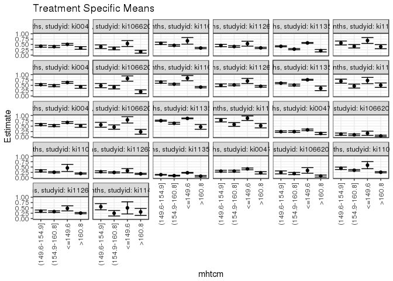

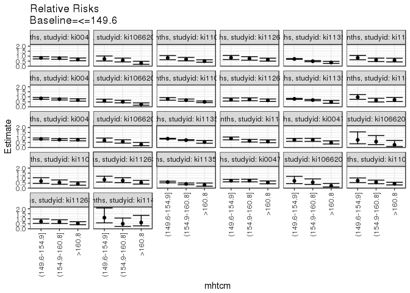

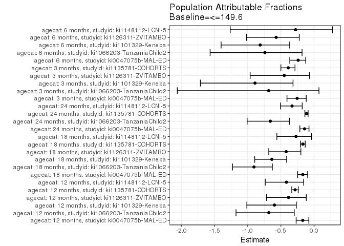

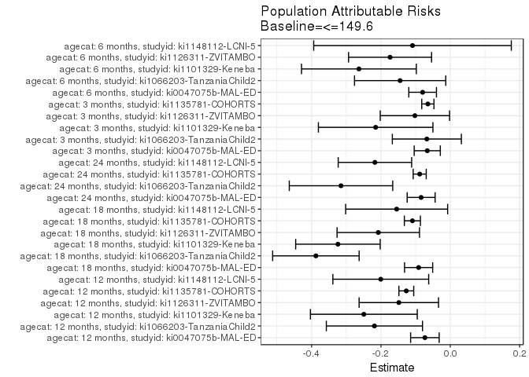

## Data Summary

| agecat | studyid | A | n | nA | nAY0 | nAY1 |
| --- | --- | --- | --- | --- | --- | --- |
| 3 months | ki0047075b-MAL-ED | <=149.6 | 1772 | 599 | 403 | 196 |
| 3 months | ki0047075b-MAL-ED | (149.6-154.9] | 1772 | 505 | 382 | 123 |
| 3 months | ki0047075b-MAL-ED | (154.9-160.8] | 1772 | 438 | 331 | 107 |
| 3 months | ki0047075b-MAL-ED | >160.8 | 1772 | 230 | 194 | 36 |
| 3 months | ki1000304b-SAS-FoodSuppl | <=149.6 | 0 | 0 | 0 | 0 |
| 3 months | ki1000304b-SAS-FoodSuppl | (149.6-154.9] | 0 | 0 | 0 | 0 |
| 3 months | ki1000304b-SAS-FoodSuppl | (154.9-160.8] | 0 | 0 | 0 | 0 |
| 3 months | ki1000304b-SAS-FoodSuppl | >160.8 | 0 | 0 | 0 | 0 |
| 3 months | ki1017093-NIH-Birth | <=149.6 | 629 | 323 | 236 | 87 |
| 3 months | ki1017093-NIH-Birth | (149.6-154.9] | 629 | 189 | 152 | 37 |
| 3 months | ki1017093-NIH-Birth | (154.9-160.8] | 629 | 100 | 85 | 15 |
| 3 months | ki1017093-NIH-Birth | >160.8 | 629 | 17 | 16 | 1 |
| 3 months | ki1017093b-PROVIDE | <=149.6 | 171 | 83 | 56 | 27 |
| 3 months | ki1017093b-PROVIDE | (149.6-154.9] | 171 | 50 | 41 | 9 |
| 3 months | ki1017093b-PROVIDE | (154.9-160.8] | 171 | 31 | 24 | 7 |
| 3 months | ki1017093b-PROVIDE | >160.8 | 171 | 7 | 7 | 0 |
| 3 months | ki1017093c-NIH-Crypto | <=149.6 | 755 | 349 | 288 | 61 |
| 3 months | ki1017093c-NIH-Crypto | (149.6-154.9] | 755 | 266 | 222 | 44 |
| 3 months | ki1017093c-NIH-Crypto | (154.9-160.8] | 755 | 124 | 108 | 16 |
| 3 months | ki1017093c-NIH-Crypto | >160.8 | 755 | 16 | 16 | 0 |
| 3 months | ki1066203-TanzaniaChild2 | <=149.6 | 596 | 54 | 45 | 9 |
| 3 months | ki1066203-TanzaniaChild2 | (149.6-154.9] | 596 | 159 | 139 | 20 |
| 3 months | ki1066203-TanzaniaChild2 | (154.9-160.8] | 596 | 245 | 221 | 24 |
| 3 months | ki1066203-TanzaniaChild2 | >160.8 | 596 | 138 | 132 | 6 |
| 3 months | ki1101329-Keneba | <=149.6 | 2059 | 35 | 19 | 16 |
| 3 months | ki1101329-Keneba | (149.6-154.9] | 2059 | 303 | 206 | 97 |
| 3 months | ki1101329-Keneba | (154.9-160.8] | 2059 | 801 | 596 | 205 |
| 3 months | ki1101329-Keneba | >160.8 | 2059 | 920 | 740 | 180 |
| 3 months | ki1112895-Guatemala BSC | <=149.6 | 0 | 0 | 0 | 0 |
| 3 months | ki1112895-Guatemala BSC | (149.6-154.9] | 0 | 0 | 0 | 0 |

[output cut: 190 more lines]

## Results Table

### Parameter: TSM

| agecat | studyid | intervention_level | baseline_level | estimate | ci_lower | ci_upper |
| --- | --- | --- | --- | --- | --- | --- |
| 3 months | ki0047075b-MAL-ED | <=149.6 | NA | 0.3272120 | 0.2896273 | 0.3647967 |
| 3 months | ki0047075b-MAL-ED | (149.6-154.9] | NA | 0.2435644 | 0.2061173 | 0.2810114 |
| 3 months | ki0047075b-MAL-ED | (154.9-160.8] | NA | 0.2442922 | 0.2040423 | 0.2845422 |
| 3 months | ki0047075b-MAL-ED | >160.8 | NA | 0.1565217 | 0.1095506 | 0.2034929 |
| 3 months | ki1066203-TanzaniaChild2 | <=149.6 | NA | 0.1666667 | 0.0671835 | 0.2661498 |
| 3 months | ki1066203-TanzaniaChild2 | (149.6-154.9] | NA | 0.1257862 | 0.0741993 | 0.1773731 |
| 3 months | ki1066203-TanzaniaChild2 | (154.9-160.8] | NA | 0.0979592 | 0.0607058 | 0.1352125 |
| 3 months | ki1066203-TanzaniaChild2 | >160.8 | NA | 0.0434783 | 0.0094252 | 0.0775314 |
| 3 months | ki1101329-Keneba | <=149.6 | NA | 0.4571429 | 0.2920652 | 0.6222205 |
| 3 months | ki1101329-Keneba | (149.6-154.9] | NA | 0.3201320 | 0.2675897 | 0.3726743 |
| 3 months | ki1101329-Keneba | (154.9-160.8] | NA | 0.2559301 | 0.2257024 | 0.2861578 |
| 3 months | ki1101329-Keneba | >160.8 | NA | 0.1956522 | 0.1700118 | 0.2212925 |
| 3 months | ki1126311-ZVITAMBO | <=149.6 | NA | 0.3294118 | 0.2294750 | 0.4293486 |
| 3 months | ki1126311-ZVITAMBO | (149.6-154.9] | NA | 0.2791878 | 0.2348832 | 0.3234924 |
| 3 months | ki1126311-ZVITAMBO | (154.9-160.8] | NA | 0.2477273 | 0.2191993 | 0.2762552 |
| 3 months | ki1126311-ZVITAMBO | >160.8 | NA | 0.1834264 | 0.1602758 | 0.2065771 |
| 3 months | ki1135781-COHORTS | <=149.6 | NA | 0.2309427 | 0.2133984 | 0.2484870 |
| 3 months | ki1135781-COHORTS | (149.6-154.9] | NA | 0.1398673 | 0.1245066 | 0.1552280 |
| 3 months | ki1135781-COHORTS | (154.9-160.8] | NA | 0.0968360 | 0.0788867 | 0.1147854 |
| 3 months | ki1135781-COHORTS | >160.8 | NA | 0.0717703 | 0.0367746 | 0.1067661 |
| 6 months | ki0047075b-MAL-ED | <=149.6 | NA | 0.4125637 | 0.3727950 | 0.4523324 |
| 6 months | ki0047075b-MAL-ED | (149.6-154.9] | NA | 0.3062880 | 0.2655871 | 0.3469890 |
| 6 months | ki0047075b-MAL-ED | (154.9-160.8] | NA | 0.3091335 | 0.2652876 | 0.3529794 |
| 6 months | ki0047075b-MAL-ED | >160.8 | NA | 0.2280702 | 0.1735912 | 0.2825491 |
| 6 months | ki1066203-TanzaniaChild2 | <=149.6 | NA | 0.3400000 | 0.2085782 | 0.4714218 |
| 6 months | ki1066203-TanzaniaChild2 | (149.6-154.9] | NA | 0.2483221 | 0.1788882 | 0.3177561 |
| 6 months | ki1066203-TanzaniaChild2 | (154.9-160.8] | NA | 0.1955556 | 0.1436836 | 0.2474276 |
| 6 months | ki1066203-TanzaniaChild2 | >160.8 | NA | 0.0775194 | 0.0313313 | 0.1237075 |
| 6 months | ki1101329-Keneba | <=149.6 | NA | 0.5882353 | 0.4227661 | 0.7537045 |
| 6 months | ki1101329-Keneba | (149.6-154.9] | NA | 0.4395973 | 0.3832302 | 0.4959645 |

[output cut: 74 more lines]

### Parameter: E(Y)

| agecat | studyid | intervention_level | baseline_level | estimate | ci_lower | ci_upper |
| --- | --- | --- | --- | --- | --- | --- |
| 3 months | ki0047075b-MAL-ED | NA | NA | 0.2607223 | 0.2581484 | 0.2632963 |
| 3 months | ki1066203-TanzaniaChild2 | NA | NA | 0.0989933 | 0.0960735 | 0.1019131 |
| 3 months | ki1101329-Keneba | NA | NA | 0.2418650 | 0.2396115 | 0.2441184 |
| 3 months | ki1126311-ZVITAMBO | NA | NA | 0.2272914 | 0.2256048 | 0.2289780 |
| 3 months | ki1135781-COHORTS | NA | NA | 0.1661754 | 0.1646633 | 0.1676875 |
| 6 months | ki0047075b-MAL-ED | NA | NA | 0.3327576 | 0.3298071 | 0.3357082 |
| 6 months | ki1066203-TanzaniaChild2 | NA | NA | 0.1952984 | 0.1888979 | 0.2016989 |
| 6 months | ki1101329-Keneba | NA | NA | 0.3246753 | 0.3214126 | 0.3279380 |
| 6 months | ki1126311-ZVITAMBO | NA | NA | 0.3038906 | 0.3015879 | 0.3061934 |
| 6 months | ki1148112-LCNI-5 | NA | NA | 0.3909774 | 0.3679040 | 0.4140509 |
| 12 months | ki0047075b-MAL-ED | NA | NA | 0.4301842 | 0.4274218 | 0.4329465 |
| 12 months | ki1066203-TanzaniaChild2 | NA | NA | 0.3211382 | 0.3113753 | 0.3309011 |
| 12 months | ki1101329-Keneba | NA | NA | 0.4173416 | 0.4136104 | 0.4210728 |
| 12 months | ki1126311-ZVITAMBO | NA | NA | 0.3857281 | 0.3835765 | 0.3878796 |
| 12 months | ki1135781-COHORTS | NA | NA | 0.4431907 | 0.4399303 | 0.4464510 |
| 12 months | ki1148112-LCNI-5 | NA | NA | 0.4812968 | 0.4715052 | 0.4910884 |
| 18 months | ki0047075b-MAL-ED | NA | NA | 0.5388440 | 0.5352798 | 0.5424082 |
| 18 months | ki1066203-TanzaniaChild2 | NA | NA | 0.4281690 | 0.4104906 | 0.4458474 |
| 18 months | ki1101329-Keneba | NA | NA | 0.5092955 | 0.5050458 | 0.5135452 |
| 18 months | ki1126311-ZVITAMBO | NA | NA | 0.4940555 | 0.4914899 | 0.4966211 |
| 18 months | ki1135781-COHORTS | NA | NA | 0.6474045 | 0.6436131 | 0.6511959 |
| 18 months | ki1148112-LCNI-5 | NA | NA | 0.5674847 | 0.5557363 | 0.5792330 |
| 24 months | ki0047075b-MAL-ED | NA | NA | 0.5869707 | 0.5837701 | 0.5901712 |
| 24 months | ki1066203-TanzaniaChild2 | NA | NA | 0.4779116 | 0.4575755 | 0.4982478 |
| 24 months | ki1135781-COHORTS | NA | NA | 0.7743436 | 0.7708841 | 0.7778031 |
| 24 months | ki1148112-LCNI-5 | NA | NA | 0.6543909 | 0.6411711 | 0.6676108 |

### Parameter: RR

| agecat | studyid | intervention_level | baseline_level | estimate | ci_lower | ci_upper |
| --- | --- | --- | --- | --- | --- | --- |
| 3 months | ki0047075b-MAL-ED | (149.6-154.9] | <=149.6 | 0.7443625 | 0.6143795 | 0.9018457 |
| 3 months | ki0047075b-MAL-ED | (154.9-160.8] | <=149.6 | 0.7465870 | 0.6107356 | 0.9126571 |
| 3 months | ki0047075b-MAL-ED | >160.8 | <=149.6 | 0.4783496 | 0.3468932 | 0.6596218 |
| 3 months | ki1066203-TanzaniaChild2 | (149.6-154.9] | <=149.6 | 0.7547170 | 0.3658160 | 1.5570606 |
| 3 months | ki1066203-TanzaniaChild2 | (154.9-160.8] | <=149.6 | 0.5877551 | 0.2896168 | 1.1928039 |
| 3 months | ki1066203-TanzaniaChild2 | >160.8 | <=149.6 | 0.2608696 | 0.0974437 | 0.6983820 |
| 3 months | ki1101329-Keneba | (149.6-154.9] | <=149.6 | 0.7002888 | 0.4709898 | 1.0412207 |
| 3 months | ki1101329-Keneba | (154.9-160.8] | <=149.6 | 0.5598471 | 0.3828838 | 0.8186001 |
| 3 months | ki1101329-Keneba | >160.8 | <=149.6 | 0.4279891 | 0.2914725 | 0.6284459 |
| 3 months | ki1126311-ZVITAMBO | (149.6-154.9] | <=149.6 | 0.8475344 | 0.6018177 | 1.1935752 |
| 3 months | ki1126311-ZVITAMBO | (154.9-160.8] | <=149.6 | 0.7520292 | 0.5436331 | 1.0403119 |
| 3 months | ki1126311-ZVITAMBO | >160.8 | <=149.6 | 0.5568303 | 0.4008850 | 0.7734387 |
| 3 months | ki1135781-COHORTS | (149.6-154.9] | <=149.6 | 0.6056362 | 0.5299282 | 0.6921603 |
| 3 months | ki1135781-COHORTS | (154.9-160.8] | <=149.6 | 0.4193077 | 0.3431897 | 0.5123082 |
| 3 months | ki1135781-COHORTS | >160.8 | <=149.6 | 0.3107712 | 0.1897234 | 0.5090501 |
| 6 months | ki0047075b-MAL-ED | (149.6-154.9] | <=149.6 | 0.7424019 | 0.6300038 | 0.8748527 |
| 6 months | ki0047075b-MAL-ED | (154.9-160.8] | <=149.6 | 0.7492989 | 0.6312156 | 0.8894723 |
| 6 months | ki0047075b-MAL-ED | >160.8 | <=149.6 | 0.5528121 | 0.4272770 | 0.7152297 |
| 6 months | ki1066203-TanzaniaChild2 | (149.6-154.9] | <=149.6 | 0.7303593 | 0.4532620 | 1.1768572 |
| 6 months | ki1066203-TanzaniaChild2 | (154.9-160.8] | <=149.6 | 0.5751634 | 0.3599117 | 0.9191502 |
| 6 months | ki1066203-TanzaniaChild2 | >160.8 | <=149.6 | 0.2279982 | 0.1120689 | 0.4638502 |
| 6 months | ki1101329-Keneba | (149.6-154.9] | <=149.6 | 0.7473154 | 0.5485857 | 1.0180366 |
| 6 months | ki1101329-Keneba | (154.9-160.8] | <=149.6 | 0.5936856 | 0.4410241 | 0.7991912 |
| 6 months | ki1101329-Keneba | >160.8 | <=149.6 | 0.4335570 | 0.3202897 | 0.5868802 |
| 6 months | ki1126311-ZVITAMBO | (149.6-154.9] | <=149.6 | 0.7268113 | 0.5422958 | 0.9741081 |
| 6 months | ki1126311-ZVITAMBO | (154.9-160.8] | <=149.6 | 0.6846715 | 0.5213261 | 0.8991975 |
| 6 months | ki1126311-ZVITAMBO | >160.8 | <=149.6 | 0.5334554 | 0.4047823 | 0.7030315 |
| 6 months | ki1148112-LCNI-5 | (149.6-154.9] | <=149.6 | 1.1111111 | 0.5943871 | 2.0770437 |
| 6 months | ki1148112-LCNI-5 | (154.9-160.8] | <=149.6 | 0.5000000 | 0.2324811 | 1.0753564 |
| 6 months | ki1148112-LCNI-5 | >160.8 | <=149.6 | 0.6250000 | 0.2901848 | 1.3461252 |
| 12 months | ki0047075b-MAL-ED | (149.6-154.9] | <=149.6 | 0.8244034 | 0.7208857 | 0.9427860 |
| 12 months | ki0047075b-MAL-ED | (154.9-160.8] | <=149.6 | 0.7896394 | 0.6838655 | 0.9117734 |
| 12 months | ki0047075b-MAL-ED | >160.8 | <=149.6 | 0.6650165 | 0.5428513 | 0.8146741 |
| 12 months | ki1066203-TanzaniaChild2 | (149.6-154.9] | <=149.6 | 0.7259259 | 0.5184189 | 1.0164916 |
| 12 months | ki1066203-TanzaniaChild2 | (154.9-160.8] | <=149.6 | 0.5809731 | 0.4189768 | 0.8056049 |
| 12 months | ki1066203-TanzaniaChild2 | >160.8 | <=149.6 | 0.2949853 | 0.1797527 | 0.4840889 |
| 12 months | ki1101329-Keneba | (149.6-154.9] | <=149.6 | 0.8250000 | 0.6416071 | 1.0608128 |
| 12 months | ki1101329-Keneba | (154.9-160.8] | <=149.6 | 0.6816479 | 0.5344977 | 0.8693095 |
| 12 months | ki1101329-Keneba | >160.8 | <=149.6 | 0.4968153 | 0.3876062 | 0.6367943 |
| 12 months | ki1126311-ZVITAMBO | (149.6-154.9] | <=149.6 | 0.8423077 | 0.6585366 | 1.0773619 |
| 12 months | ki1126311-ZVITAMBO | (154.9-160.8] | <=149.6 | 0.7516657 | 0.5965577 | 0.9471025 |
| 12 months | ki1126311-ZVITAMBO | >160.8 | <=149.6 | 0.6334366 | 0.5020106 | 0.7992697 |
| 12 months | ki1135781-COHORTS | (149.6-154.9] | <=149.6 | 0.7195548 | 0.6735286 | 0.7687262 |
| 12 months | ki1135781-COHORTS | (154.9-160.8] | <=149.6 | 0.4915872 | 0.4419715 | 0.5467727 |
| 12 months | ki1135781-COHORTS | >160.8 | <=149.6 | 0.3635550 | 0.2752026 | 0.4802724 |
| 12 months | ki1148112-LCNI-5 | (149.6-154.9] | <=149.6 | 0.8306785 | 0.6413148 | 1.0759563 |
| 12 months | ki1148112-LCNI-5 | (154.9-160.8] | <=149.6 | 0.6068966 | 0.4586253 | 0.8031032 |
| 12 months | ki1148112-LCNI-5 | >160.8 | <=149.6 | 0.5777778 | 0.4206799 | 0.7935420 |
| 18 months | ki0047075b-MAL-ED | (149.6-154.9] | <=149.6 | 0.8400204 | 0.7544184 | 0.9353355 |
| 18 months | ki0047075b-MAL-ED | (154.9-160.8] | <=149.6 | 0.7650186 | 0.6778354 | 0.8634152 |
| 18 months | ki0047075b-MAL-ED | >160.8 | <=149.6 | 0.6756783 | 0.5700367 | 0.8008978 |
| 18 months | ki1066203-TanzaniaChild2 | (149.6-154.9] | <=149.6 | 0.5943304 | 0.4612719 | 0.7657709 |
| 18 months | ki1066203-TanzaniaChild2 | (154.9-160.8] | <=149.6 | 0.5063114 | 0.3942679 | 0.6501954 |
| 18 months | ki1066203-TanzaniaChild2 | >160.8 | <=149.6 | 0.2451613 | 0.1541134 | 0.3899988 |
| 18 months | ki1101329-Keneba | (149.6-154.9] | <=149.6 | 0.7771429 | 0.6574179 | 0.9186713 |
| 18 months | ki1101329-Keneba | (154.9-160.8] | <=149.6 | 0.6620155 | 0.5645086 | 0.7763647 |
| 18 months | ki1101329-Keneba | >160.8 | <=149.6 | 0.4961915 | 0.4206427 | 0.5853092 |
| 18 months | ki1126311-ZVITAMBO | (149.6-154.9] | <=149.6 | 0.7125000 | 0.5769303 | 0.8799265 |
| 18 months | ki1126311-ZVITAMBO | (154.9-160.8] | <=149.6 | 0.7393627 | 0.6131087 | 0.8916153 |
| 18 months | ki1126311-ZVITAMBO | >160.8 | <=149.6 | 0.6453647 | 0.5342274 | 0.7796224 |
| 18 months | ki1135781-COHORTS | (149.6-154.9] | <=149.6 | 0.7894555 | 0.7457315 | 0.8357430 |
| 18 months | ki1135781-COHORTS | (154.9-160.8] | <=149.6 | 0.6759082 | 0.6181942 | 0.7390102 |
| 18 months | ki1135781-COHORTS | >160.8 | <=149.6 | 0.4743215 | 0.3520422 | 0.6390737 |
| 18 months | ki1148112-LCNI-5 | (149.6-154.9] | <=149.6 | 0.9585799 | 0.7503431 | 1.2246069 |
| 18 months | ki1148112-LCNI-5 | (154.9-160.8] | <=149.6 | 0.6419580 | 0.4823666 | 0.8543504 |
| 18 months | ki1148112-LCNI-5 | >160.8 | <=149.6 | 0.7000864 | 0.5243917 | 0.9346467 |
| 24 months | ki0047075b-MAL-ED | (149.6-154.9] | <=149.6 | 0.8509889 | 0.7692306 | 0.9414369 |
| 24 months | ki0047075b-MAL-ED | (154.9-160.8] | <=149.6 | 0.7827913 | 0.6989207 | 0.8767264 |
| 24 months | ki0047075b-MAL-ED | >160.8 | <=149.6 | 0.7676195 | 0.6621321 | 0.8899127 |
| 24 months | ki1066203-TanzaniaChild2 | (149.6-154.9] | <=149.6 | 0.7103491 | 0.5384185 | 0.9371814 |
| 24 months | ki1066203-TanzaniaChild2 | (154.9-160.8] | <=149.6 | 0.5767808 | 0.4321360 | 0.7698411 |
| 24 months | ki1066203-TanzaniaChild2 | >160.8 | <=149.6 | 0.2980237 | 0.1787592 | 0.4968590 |
| 24 months | ki1135781-COHORTS | (149.6-154.9] | <=149.6 | 0.8745175 | 0.8401164 | 0.9103273 |
| 24 months | ki1135781-COHORTS | (154.9-160.8] | <=149.6 | 0.7338285 | 0.6847808 | 0.7863892 |
| 24 months | ki1135781-COHORTS | >160.8 | <=149.6 | 0.5409922 | 0.4243140 | 0.6897545 |
| 24 months | ki1148112-LCNI-5 | (149.6-154.9] | <=149.6 | 0.8909195 | 0.7599552 | 1.0444530 |
| 24 months | ki1148112-LCNI-5 | (154.9-160.8] | <=149.6 | 0.6635877 | 0.5464477 | 0.8058387 |
| 24 months | ki1148112-LCNI-5 | >160.8 | <=149.6 | 0.5990196 | 0.4751301 | 0.7552131 |

### Parameter: PAR

| agecat | studyid | intervention_level | baseline_level | estimate | ci_lower | ci_upper |
| --- | --- | --- | --- | --- | --- | --- |
| 3 months | ki0047075b-MAL-ED | <=149.6 | NA | -0.0664897 | -0.1041624 | -0.0288169 |
| 3 months | ki1066203-TanzaniaChild2 | <=149.6 | NA | -0.0676734 | -0.1671994 | 0.0318526 |
| 3 months | ki1101329-Keneba | <=149.6 | NA | -0.2152779 | -0.3803709 | -0.0501848 |
| 3 months | ki1126311-ZVITAMBO | <=149.6 | NA | -0.1021204 | -0.2020714 | -0.0021693 |
| 3 months | ki1135781-COHORTS | <=149.6 | NA | -0.0647673 | -0.0823767 | -0.0471580 |
| 6 months | ki0047075b-MAL-ED | <=149.6 | NA | -0.0798060 | -0.1196840 | -0.0399280 |
| 6 months | ki1066203-TanzaniaChild2 | <=149.6 | NA | -0.1447016 | -0.2762792 | -0.0131240 |
| 6 months | ki1101329-Keneba | <=149.6 | NA | -0.2635600 | -0.4290614 | -0.0980586 |
| 6 months | ki1126311-ZVITAMBO | <=149.6 | NA | -0.1737213 | -0.2933787 | -0.0540639 |
| 6 months | ki1148112-LCNI-5 | <=149.6 | NA | -0.1090226 | -0.3939244 | 0.1758793 |
| 12 months | ki0047075b-MAL-ED | <=149.6 | NA | -0.0733246 | -0.1144755 | -0.0321736 |
| 12 months | ki1066203-TanzaniaChild2 | <=149.6 | NA | -0.2188618 | -0.3574928 | -0.0802308 |
| 12 months | ki1101329-Keneba | <=149.6 | NA | -0.2493251 | -0.4033963 | -0.0952539 |
| 12 months | ki1126311-ZVITAMBO | <=149.6 | NA | -0.1485185 | -0.2629952 | -0.0340418 |
| 12 months | ki1135781-COHORTS | <=149.6 | NA | -0.1268851 | -0.1482510 | -0.1055192 |
| 12 months | ki1148112-LCNI-5 | <=149.6 | NA | -0.2005214 | -0.3386647 | -0.0623782 |
| 18 months | ki0047075b-MAL-ED | <=149.6 | NA | -0.0913928 | -0.1319432 | -0.0508424 |
| 18 months | ki1066203-TanzaniaChild2 | <=149.6 | NA | -0.3876205 | -0.5123085 | -0.2629325 |
| 18 months | ki1101329-Keneba | <=149.6 | NA | -0.3240378 | -0.4458810 | -0.2021947 |
| 18 months | ki1126311-ZVITAMBO | <=149.6 | NA | -0.2076989 | -0.3265313 | -0.0888665 |
| 18 months | ki1135781-COHORTS | <=149.6 | NA | -0.1094120 | -0.1325539 | -0.0862701 |
| 18 months | ki1148112-LCNI-5 | <=149.6 | NA | -0.1547376 | -0.3017450 | -0.0077301 |
| 24 months | ki0047075b-MAL-ED | <=149.6 | NA | -0.0841320 | -0.1244219 | -0.0438421 |
| 24 months | ki1066203-TanzaniaChild2 | <=149.6 | NA | -0.3151918 | -0.4643135 | -0.1660701 |
| 24 months | ki1135781-COHORTS | <=149.6 | NA | -0.0882690 | -0.1070804 | -0.0694576 |
| 24 months | ki1148112-LCNI-5 | <=149.6 | NA | -0.2174039 | -0.3233054 | -0.1115024 |

### Parameter: PAF

| agecat | studyid | intervention_level | baseline_level | estimate | ci_lower | ci_upper |
| --- | --- | --- | --- | --- | --- | --- |
| 3 months | ki0047075b-MAL-ED | <=149.6 | NA | -0.2550210 | -0.4083787 | -0.1183623 |
| 3 months | ki1066203-TanzaniaChild2 | <=149.6 | NA | -0.6836158 | -2.0604778 | 0.0738171 |
| 3 months | ki1101329-Keneba | <=149.6 | NA | -0.8900746 | -1.7124271 | -0.3170426 |
| 3 months | ki1126311-ZVITAMBO | <=149.6 | NA | -0.4492926 | -0.9631413 | -0.0699429 |
| 3 months | ki1135781-COHORTS | <=149.6 | NA | -0.3897528 | -0.5002582 | -0.2873870 |
| 6 months | ki0047075b-MAL-ED | <=149.6 | NA | -0.2398323 | -0.3658504 | -0.1254412 |
| 6 months | ki1066203-TanzaniaChild2 | <=149.6 | NA | -0.7409259 | -1.5659757 | -0.1811581 |
| 6 months | ki1101329-Keneba | <=149.6 | NA | -0.8117647 | -1.4007435 | -0.3672812 |
| 6 months | ki1126311-ZVITAMBO | <=149.6 | NA | -0.5716573 | -1.0192608 | -0.2232727 |
| 6 months | ki1148112-LCNI-5 | <=149.6 | NA | -0.2788462 | -1.2635811 | 0.2774955 |
| 12 months | ki0047075b-MAL-ED | <=149.6 | NA | -0.1704493 | -0.2702123 | -0.0785216 |
| 12 months | ki1066203-TanzaniaChild2 | <=149.6 | NA | -0.6815190 | -1.1762046 | -0.2992832 |
| 12 months | ki1101329-Keneba | <=149.6 | NA | -0.5974125 | -1.0129414 | -0.2676606 |
| 12 months | ki1126311-ZVITAMBO | <=149.6 | NA | -0.3850342 | -0.7160694 | -0.1178568 |
| 12 months | ki1135781-COHORTS | <=149.6 | NA | -0.2862991 | -0.3358033 | -0.2386295 |
| 12 months | ki1148112-LCNI-5 | <=149.6 | NA | -0.4166274 | -0.7356827 | -0.1562212 |
| 18 months | ki0047075b-MAL-ED | <=149.6 | NA | -0.1696090 | -0.2474511 | -0.0966243 |
| 18 months | ki1066203-TanzaniaChild2 | <=149.6 | NA | -0.9052978 | -1.2288151 | -0.6287397 |
| 18 months | ki1101329-Keneba | <=149.6 | NA | -0.6362472 | -0.8941425 | -0.4134654 |
| 18 months | ki1126311-ZVITAMBO | <=149.6 | NA | -0.4203959 | -0.6825525 | -0.1990856 |
| 18 months | ki1135781-COHORTS | <=149.6 | NA | -0.1690010 | -0.2054797 | -0.1336262 |
| 18 months | ki1148112-LCNI-5 | <=149.6 | NA | -0.2726727 | -0.5606000 | -0.0378673 |
| 24 months | ki0047075b-MAL-ED | <=149.6 | NA | -0.1433325 | -0.2141458 | -0.0766493 |
| 24 months | ki1066203-TanzaniaChild2 | <=149.6 | NA | -0.6595190 | -1.0089112 | -0.3708934 |
| 24 months | ki1135781-COHORTS | <=149.6 | NA | -0.1139920 | -0.1386531 | -0.0898650 |
| 24 months | ki1148112-LCNI-5 | <=149.6 | NA | -0.3322233 | -0.5053954 | -0.1789720 |